# Cats vs Dogs Dataset - Using CNN

### You can get the dataset from here: https://download.microsoft.com/download/3/E/1/3E1C3F21-ECDB-4869-8368-6DEBA77B919F/kagglecatsanddogs_5340.zip

```python
import os
import zipfile
import random
import shutil
import tensorflow as tf
from tensorflow.keras.preprocessing.image import ImageDataGenerator
from shutil import copyfile
import matplotlib.pyplot as plt
```

Now the images are stored within the `C:\Users\User\Downloads\PetImages` directory. There is a subdirectory for each class, so one for dogs and one for cats.

```python
source_path = r'C:\Users\User\Downloads\PetImages'

source_path_dogs = os.path.join(source_path, 'Dog')
source_path_cats = os.path.join(source_path, 'Cat')


# os.listdir returns a list containing all files under the given path
print(f"There are {len(os.listdir(source_path_dogs))} images of dogs.")
print(f"There are {len(os.listdir(source_path_cats))} images of cats.")
```

```
There are 12501 images of dogs.
There are 12501 images of cats.
```

You will need a directory for cats-v-dogs, and subdirectories for training and validation. These in turn will need subdirectories for 'cats' and 'dogs':

```python
# Define root directory
root_dir = r'C:\Users\User\Downloads\PetImages\cats-v-dogs'

# Empty directory to prevent FileExistsError is the function is run several times
if os.path.exists(root_dir):
  shutil.rmtree(root_dir)

try:

    traindir = "training"
    valdir = "validation"
    catsdir = "cats"
    dogsdir = "dogs"

    # Create training and validation directories along with subdirectories using makedirs
    training = os.path.join(root_dir,traindir)
    validation = os.path.join(root_dir,valdir)
    os.makedirs(root_dir)
    os.makedirs(training)
    os.makedirs(validation)
    os.makedirs(os.path.join(training,catsdir))
    os.makedirs(os.path.join(training,dogsdir))
    os.makedirs(os.path.join(validation,catsdir))
    os.makedirs(os.path.join(validation,dogsdir))

except FileExistsError:
  print("You should not be seeing this since the upper directory is removed beforehand")
```

Let's check our structure:

```python
for rootdir, dirs, files in os.walk(root_dir):
    for subdir in dirs:
        print(os.path.join(rootdir, subdir))
```

```
C:\Users\User\Downloads\PetImages\cats-v-dogs\training
C:\Users\User\Downloads\PetImages\cats-v-dogs\validation
C:\Users\User\Downloads\PetImages\cats-v-dogs\training\cats
C:\Users\User\Downloads\PetImages\cats-v-dogs\training\dogs
C:\Users\User\Downloads\PetImages\cats-v-dogs\validation\cats
C:\Users\User\Downloads\PetImages\cats-v-dogs\validation\dogs
```

### Data splitting and preparation

The files will be randomized, so that the training set is a random sample of the files, and the validation set is made up of the remaining files.

`split_size` will be the percentage of the training set

Let's create a function to do so:

```python
def split_data(SOURCE_DIR, TRAINING_DIR, VALIDATION_DIR, SPLIT_SIZE):
  """
  Splits the data into train and test sets

  Args:
    SOURCE_DIR (string): directory path containing the images
    TRAINING_DIR (string): directory path to be used for training
    VALIDATION_DIR (string): directory path to be used for validation
    SPLIT_SIZE (float): proportion of the dataset to be used for training

  Returns:
    None
  """

  images_count = len(os.listdir(SOURCE_DIR))
  training_count = int(images_count * SPLIT_SIZE)+1
  validation_count = int(images_count - training_count)
  images = os.listdir(SOURCE_DIR)
  training_images = random.sample(images,training_count)
  validation_images = []
  train_counter = 0
  val_counter = 0

  for image in training_images:
    if image in images:
        images.remove(image)

  validation_images = images

  for train_counter in  range(training_count):
    if os.path.getsize(os.path.join(SOURCE_DIR,training_images[train_counter])) == 0:
      print(f"{training_images[train_counter]} is zero length, so ignoring.")
    else:
      copyfile(os.path.join(SOURCE_DIR,training_images[train_counter]), os.path.join(TRAINING_DIR,training_images[train_counter]))
    train_counter = train_counter + 1
  for val_counter in  range(validation_count):
    if os.path.getsize(os.path.join(SOURCE_DIR,validation_images[val_counter])) == 0:
      print(f"{validation_images[val_counter]} is zero length, so ignoring.")
    else:
      copyfile(os.path.join(SOURCE_DIR,validation_images[val_counter]), os.path.join(VALIDATION_DIR,validation_images[val_counter]))
    val_counter = val_counter + 1
```

```python
# Define paths
CAT_SOURCE_DIR = r'C:\Users\User\Downloads\PetImages\Cat'
DOG_SOURCE_DIR = r'C:\Users\User\Downloads\PetImages\Dog'

TRAINING_DIR = r'C:\Users\User\Downloads\PetImages\cats-v-dogs\training'
VALIDATION_DIR = r'C:\Users\User\Downloads\PetImages\cats-v-dogs\validation'

TRAINING_CATS_DIR = os.path.join(TRAINING_DIR, "cats/")
VALIDATION_CATS_DIR = os.path.join(VALIDATION_DIR, "cats/")

TRAINING_DOGS_DIR = os.path.join(TRAINING_DIR, "dogs/")
VALIDATION_DOGS_DIR = os.path.join(VALIDATION_DIR, "dogs/")

# Empty directories in case we run this cell multiple times
if len(os.listdir(TRAINING_CATS_DIR)) > 0:
  for file in os.scandir(TRAINING_CATS_DIR):
    os.remove(file.path)
if len(os.listdir(TRAINING_DOGS_DIR)) > 0:
  for file in os.scandir(TRAINING_DOGS_DIR):
    os.remove(file.path)
if len(os.listdir(VALIDATION_CATS_DIR)) > 0:
  for file in os.scandir(VALIDATION_CATS_DIR):
    os.remove(file.path)
if len(os.listdir(VALIDATION_DOGS_DIR)) > 0:
  for file in os.scandir(VALIDATION_DOGS_DIR):
    os.remove(file.path)

# Define proportion of images used for training
split_size = .9

# Run the function
split_data(CAT_SOURCE_DIR, TRAINING_CATS_DIR, VALIDATION_CATS_DIR, split_size)
split_data(DOG_SOURCE_DIR, TRAINING_DOGS_DIR, VALIDATION_DOGS_DIR, split_size)

# Check that the number of images
print(f"\n\nThere are {len(os.listdir(TRAINING_CATS_DIR))} images of cats for training")
print(f"There are {len(os.listdir(TRAINING_DOGS_DIR))} images of dogs for training")
print(f"There are {len(os.listdir(VALIDATION_CATS_DIR))} images of cats for validation")
print(f"There are {len(os.listdir(VALIDATION_DOGS_DIR))} images of dogs for validation")
```

```
666.jpg is zero length, so ignoring.
11702.jpg is zero length, so ignoring.


There are 11250 images of cats for training
There are 11251 images of dogs for training
There are 1250 images of cats for validation
There are 1249 images of dogs for validation
```

Now that we have successfully organized the data in a way that can be easily fed to Keras' `ImageDataGenerator`, it is time to code the generators that will yield batches of images, both for training and validation.

`flow_from_directory` method allows us to standarize this by defining a tuple called `target_size` that will be used to convert each image to this target resolution. **we will use `target_size` of (150, 150)**.

```python
# Instantiate the ImageDataGenerator class and rescale for training
train_datagen = ImageDataGenerator( rescale = 1.0/255. )

train_generator = train_datagen.flow_from_directory(directory=TRAINING_DIR,
                                                  batch_size=32,
                                                  class_mode='binary',
                                                  target_size=(150, 150))

# Instantiate the ImageDataGenerator class and rescale for validation
validation_datagen = ImageDataGenerator( rescale = 1.0/255. )

validation_generator = validation_datagen.flow_from_directory(directory=VALIDATION_DIR,
                                                            batch_size=32,
                                                            class_mode='binary',
                                                            target_size=(150, 150))
```

```
Found 22499 images belonging to 2 classes.
Found 2499 images belonging to 2 classes.
```

### Creating our model

```python
from tensorflow.keras.optimizers import RMSprop

model = tf.keras.models.Sequential([
            tf.keras.layers.Conv2D(16, (3,3), activation='relu', input_shape=(150, 150, 3)),
            tf.keras.layers.MaxPooling2D(2,2),
            tf.keras.layers.Conv2D(32, (3,3), activation='relu'),
            tf.keras.layers.MaxPooling2D(2,2),
            tf.keras.layers.Conv2D(64, (3,3), activation='relu'),
            tf.keras.layers.MaxPooling2D(2,2),
            tf.keras.layers.Conv2D(64, (3,3), activation='relu'),
            tf.keras.layers.MaxPooling2D(2,2),
            tf.keras.layers.Conv2D(64, (3,3), activation='relu'),
            tf.keras.layers.MaxPooling2D(2,2),
            tf.keras.layers.Flatten(),
            tf.keras.layers.Dense(512, activation='relu'),
            tf.keras.layers.Dense(1, activation='sigmoid')
            ])


model.compile(optimizer=RMSprop(learning_rate=0.001),
            loss='binary_crossentropy',
            metrics=['accuracy'])
```

### Let's check our architechture:

```python
model.summary()
```

```
Model: "sequential"
_________________________________________________________________
 Layer (type)                Output Shape              Param #
=================================================================
 conv2d (Conv2D)             (None, 148, 148, 16)      448

 max_pooling2d (MaxPooling2D  (None, 74, 74, 16)       0
 )

 conv2d_1 (Conv2D)           (None, 72, 72, 32)        4640

 max_pooling2d_1 (MaxPooling  (None, 36, 36, 32)       0
 2D)

 conv2d_2 (Conv2D)           (None, 34, 34, 64)        18496

 max_pooling2d_2 (MaxPooling  (None, 17, 17, 64)       0
 2D)

 conv2d_3 (Conv2D)           (None, 15, 15, 64)        36928

 max_pooling2d_3 (MaxPooling  (None, 7, 7, 64)         0
 2D)

 conv2d_4 (Conv2D)           (None, 5, 5, 64)          36928

 max_pooling2d_4 (MaxPooling  (None, 2, 2, 64)         0
 2D)

 flatten (Flatten)           (None, 256)               0

 dense (Dense)               (None, 512)               131584

 dense_1 (Dense)             (None, 1)                 513

=================================================================
Total params: 229,537
Trainable params: 229,537
Non-trainable params: 0
_________________________________________________________________
```

### Now, let's train the model

```python
# Train the model
history = model.fit(train_generator,
                    epochs=15,
                    verbose=1,
                    validation_data=validation_generator)
```

[output not shown]

Let's run the below cell to check the training and validation accuracy achieved at the end of each epoch.

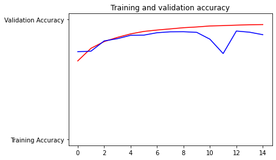

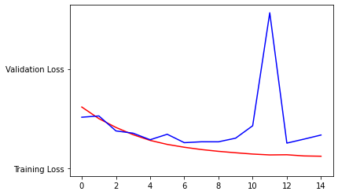

```python
#-----------------------------------------------------------
# Retrieve a list of list results on training and test data
# sets for each training epoch
#-----------------------------------------------------------
acc=history.history['accuracy']
val_acc=history.history['val_accuracy']
loss=history.history['loss']
val_loss=history.history['val_loss']

epochs=range(len(acc)) # Get number of epochs

#------------------------------------------------
# Plot training and validation accuracy per epoch
#------------------------------------------------
plt.plot(epochs, acc, 'r', "Training Accuracy")
plt.plot(epochs, val_acc, 'b', "Validation Accuracy")
plt.title('Training and validation accuracy')
plt.show()
print("")

#------------------------------------------------
# Plot training and validation loss per epoch
#------------------------------------------------
plt.plot(epochs, loss, 'r', "Training Loss")
plt.plot(epochs, val_loss, 'b', "Validation Loss")
plt.show()
```

You will probably encounter that the model is overfitting, which means that it is doing a great job at classifying the images in the training set but struggles with new data.